# Data visualization

Let’s see if we can get any more insights by visualizing the data.

```r
source('~/ncr_notebooks/baseline_prediction/src/aux_functions.R')
source('~/ncr_notebooks/baseline_prediction/src/load_raw_voting_data.R')
```

```
[1] "Loading DTI tracts"
[1] "Loading structural ROIs"
[1] "Loading neuropsych"
[1] "Loading GeoSpatial"
[1] "Loading PRS"
```

```r
library(caret)
adhd_idx = gf_base$DX_BASELINE!='NV'
```

First let’s figure out if the ADHD symptoms for the kid persisted or remitted in their last visit:

```r
out_group = c()
for (s in gf_base[adhd_idx,]$MRN) {
  idx = which(gf$MRN==s)
  subj_sx = gf[idx, c('SX_inatt', 'SX_HI')]
  last_age = sort(gf[idx,]$age, index.return=T, decreasing=T)
  last_sx = subj_sx[last_age$ix[1], ]
  if (last_age$x[1] > 18) {
    # adult
    if (last_sx$SX_inatt > 4 || last_sx$SX_HI > 4) {
      out_group = c(out_group, 'persistent')
    } else {
      out_group = c(out_group, 'remission')
    }
  } else {
    # child
    if (last_sx$SX_inatt > 5 || last_sx$SX_HI > 5) {
      out_group = c(out_group, 'persistent')
    } else {
      out_group = c(out_group, 'remission')
    }
  }
}
out_group = factor(out_group, levels=c('remission', 'persistent'))
```

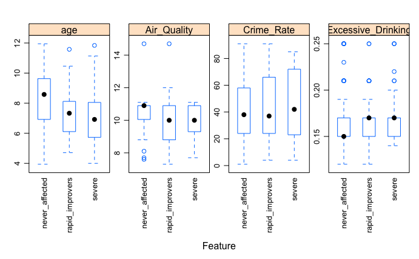

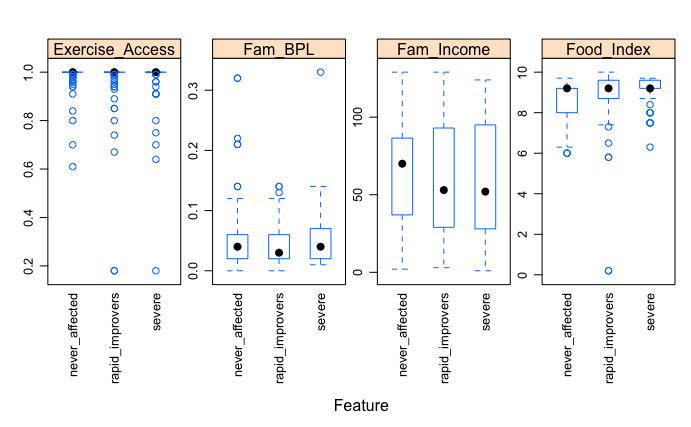

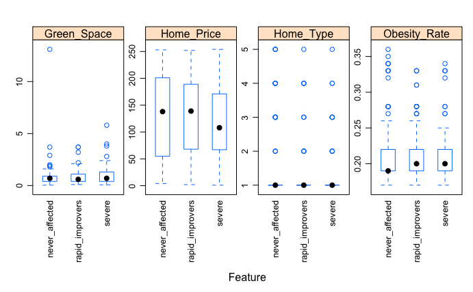

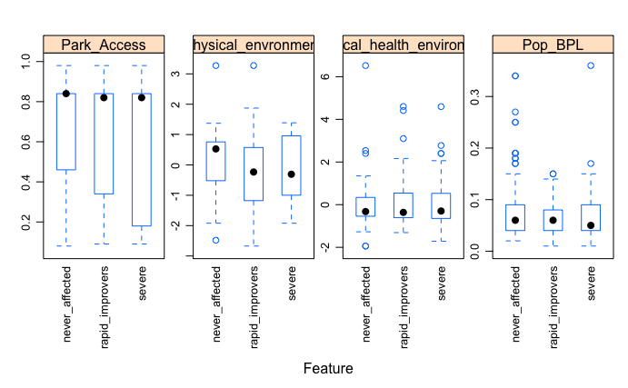

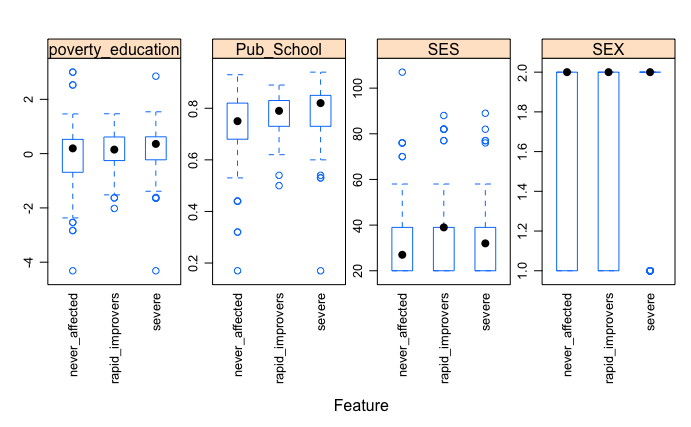

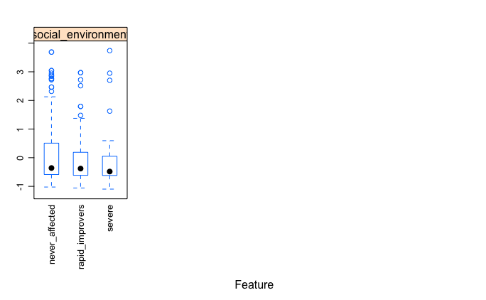

```r
X = geospatial
# recoding SEX
X$SEX = as.numeric(X$SEX)
# dummies = dummyVars(~SEX, data=X)
# X = cbind(X, predict(dummies, newdata=X))
# X$SEX = NULL
# removing anyone that is all NaNs for this dataset
rm_me = rowSums(is.na(X)) == ncol(X)
X = X[!rm_me,]
y = y[!rm_me]
featurePlot(x = X,
            y = gf_base$HI3_named,
            plot = "box",
            ## Pass in options to bwplot()
            scales = list(y = list(relation="free"),
                          x = list(rot = 90)),
            layout = c(4,1 ),
            auto.key = list(columns = 2))
```

It looks like we have a whole lot of outliers! What can we do to clean them up a bit?

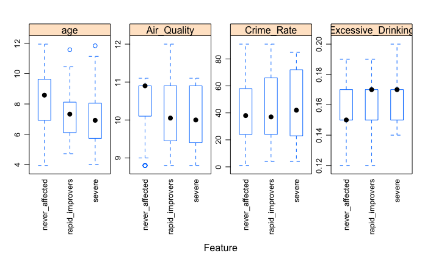

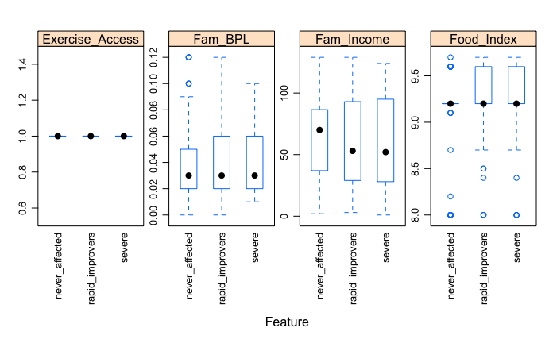

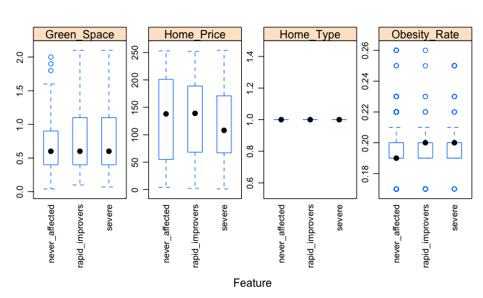

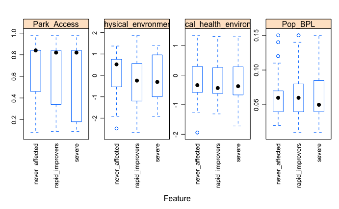

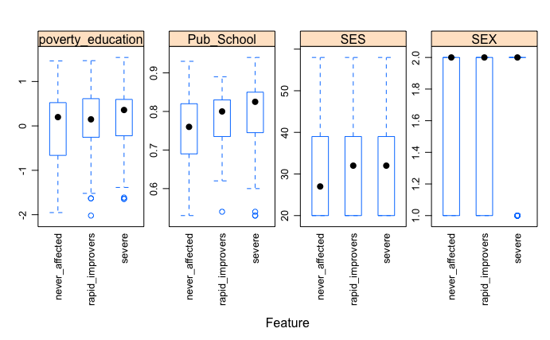

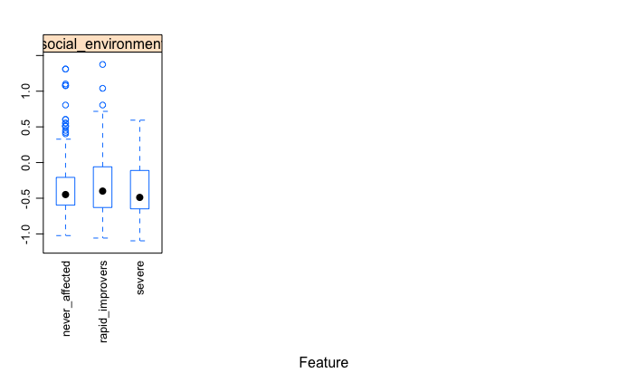

```r
cleanX = sapply(X, function(d) {outlier = boxplot.stats(d)$out; return(ifelse(d %in% outlier, NA, d))})
featurePlot(x = cleanX,
            y = gf_base$HI3_named,
            plot = "box",
            ## Pass in options to bwplot()
            scales = list(y = list(relation="free"),
                          x = list(rot = 90)),
            layout = c(4,1 ),
            auto.key = list(columns = 2))
```

This looks a bit better. We do need to remove a few variables that don’t make much sense anymore, like the PCs, and some non-informative variables. Not sure if it’ll make a difference in terms of prediction, though.

```r
rm_me = which(colnames(X) %in% c('Exercise_Access', 'social_environment',
                                 'physical_envronment', 'physical_health_environment',
                                 'Home_Type', 'SEX', 'age'))
cleanX = cleanX[, -rm_me]
cleanX = cbind(cleanX, X[, c('SEX', 'age')])  # making sure we didn't clean those 2
```

In any case, let’s make a few other plots:

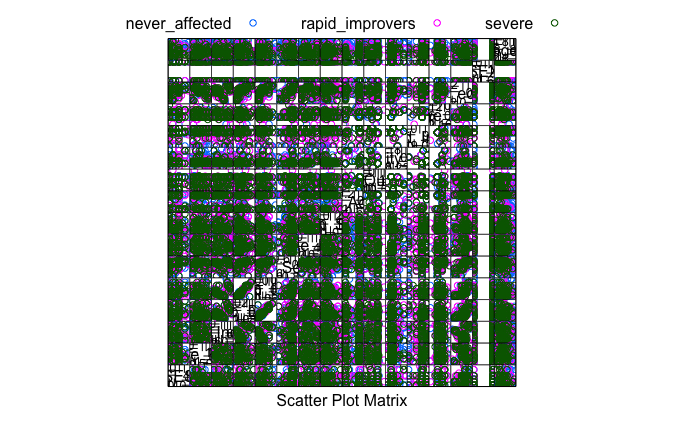

```r
featurePlot(x = cleanX,
            y = gf_base$HI3_named,
            plot = "pairs",
            ## Add a key at the top
            auto.key = list(columns = 3))
```

I honestly don’t think these types of oplots will be too useful, as we won’t be able to observe more than a handful of variable interaction. We can, however, do the exact type pe cleaning we did above for other variable types:

```r
dsets = c('prs', 'geospatial', 'neuropsych', 'dti_tracts', 'struct_rois')
for (dset in dsets) {
  print(sprintf('cleaning %s', dset))
  eval(parse(text=sprintf('X = %s', dset)))
  X$SEX = as.numeric(X$SEX)
  # removing anyone that is all NaNs for this dataset
  rm_me = rowSums(is.na(X)) == ncol(X)
  X = X[!rm_me,]
  rm_me = which(colnames(X) %in% c('Exercise_Access', 'social_environment',
                                 'physical_envronment', 'physical_health_environment',
                                 'Home_Type', 'SEX', 'age'))
  cleanX = sapply(X, function(d) {outlier = boxplot.stats(d)$out; return(ifelse(d %in% outlier, NA, d))})
  cleanX = cleanX[, -rm_me]
  cleanX = cbind(cleanX, X[, c('SEX', 'age')])  # making sure we didn't clean those 2
  print(sprintf('Before cleaning: %d NAs', sum(is.na(X))))
  print(sprintf('Before cleaning: %d NAs', sum(is.na(cleanX))))
}
```

```
[1] "cleaning prs"
[1] "Before cleaning: 198 NAs"
[1] "Before cleaning: 269 NAs"
[1] "cleaning geospatial"
[1] "Before cleaning: 12 NAs"
[1] "Before cleaning: 210 NAs"
[1] "cleaning neuropsych"
[1] "Before cleaning: 1582 NAs"
[1] "Before cleaning: 1674 NAs"
[1] "cleaning dti_tracts"
[1] "Before cleaning: 970 NAs"
[1] "Before cleaning: 1065 NAs"
[1] "cleaning struct_rois"
[1] "Before cleaning: 5408 NAs"
[1] "Before cleaning: 6047 NAs"
```

So, we can certainly remove some of the outliers, but whether that makes a difference in prediction results is still to be seen. In fact, tree-based classifiers shouldn’t care too much about outliers anyways, and neither should SVMs as long as the outliers are not vectors.